# Applying clustering algorithms on movement metrics

Wenjing Xu 徐雯靓 (wenjing.xu@senckenberg.de)

03 August 2025

## 1. Introduction

The goal of this analysis is to identify distinct movement strategies among wildebeest individuals based on movement-derived summary metrics. We apply both hierarchical and k-means clustering to explore individual-level patterns in:

- displacement
- path straightness
- intensity of space use
- minimum convex polygon (MCP) area

The two main clustering methods used in this workshop are:

- **Hierarchical clustering**, which builds a tree-like structure of nested groups without pre-specifying the number of clusters.
- **K-means clustering**, which partitions the data into a pre-defined number of clusters by minimizing within-cluster variance.

Why clustering?

- Clustering provides an unsupervised, data-driven way to group individuals based on multivariate movement patterns.
- It is simpler and more interpretable than behavioral segmentation methods (e.g. state‑space models), especially at the individual level.
- Clustering enables exploration of general movement syndromes before applying more complex behavioral modeling.

## 2. Load and Prepare Data

```r
load("./Data/wildebeest_data.rdata")

# filter to more accurate data points
WB <- WB %>%
  as_tibble() %>%
  filter((fixType == "3D" & as.numeric(DOP) < 10) |
         (fixType == "2D" & as.numeric(DOP) < 5))

# some individuals have less than one year amount of data
# to make sure the movement metrics are comparable, we subset the dataset
# to contain only individuals with at least one year amount of data
# and subset the data to contain only data between Nov 1st 2010 and Oct 31 2011.

# first create a summary table for the dataset
WB_summary <- WB %>%
  arrange(animal_id, timestamp) %>%
  group_by(animal_id) %>%
  summarise(
    start_time = min(timestamp, na.rm = TRUE),
    end_time = max(timestamp, na.rm = TRUE),
    total_duration_days = as.numeric(difftime(end_time, start_time, units = "days")),
    interval_h = median(as.numeric(diff(timestamp), units = "hours"), na.rm = TRUE),
    n_fixes = n(),
    .groups = "drop"
  )

# find individuals that were tracked for more tha one year
long_term_ids <- WB_summary %>%
  filter(total_duration_days >= 365) %>%
  pull(animal_id)

# filter to only these individuals and the same time period
WB.one.year <- WB %>%
  filter(animal_id %in% long_term_ids) %>%
  filter(timestamp >= ymd("2010-11-01") & timestamp <= ymd("2011-10-31"))

# turn the subset to tracks
wb.trk <- make_track(WB.one.year,
                     # tell the function which column contains the coordinates
                     .x = longitude, .y = latitude,
                     # tell the function which CRS the coordinates are based on.
                     crs = 4326,
                     .t = timestamp,
                     # any additional information you want to attach to the track
                     # such as animal ID and month
                     id = animal_id, sex = sex, temp = temp)

# nest the tracks to prep for metrics calculation
wb.trk.nested <- wb.trk %>%
  transform_coords(., 32737) %>%
  nest(data = -"id")
```

## 3. Define and Compute Movement Metrics

Because we will calculate the same metrics across all individuals at different temporal intervals (day, week, or year), we can define the functions first then apply to the tracks using `map`.

```r
# calculating displacement at the given temporal scale
calc_disp <- function(track_df, time_unit = c("day", "week")) {

  time_unit <- match.arg(time_unit)

  # for each temporal group, calculate distance between the first and the last locations (i.e. displacement)
  track_df %>%
    mutate(period = floor_date(t_, unit = time_unit)) %>%
    arrange(t_) %>%
    group_by(period) %>%
    summarise(
      x_start = first(x_),
      y_start = first(y_),
      x_end   = last(x_),
      y_end   = last(y_),
      .groups = "drop"
    ) %>%
    mutate(
      displacement = sqrt((x_end - x_start)^2 + (y_end - y_start)^2)
    )
}

# calc maximum displacement monthly and annually
calc_max_disp <- function(track_df, time_unit = c("month", "year")) {

  # if temporal period is year, calculate maximum displacement for the entire track
  if (time_unit == "year") {
    coords <- track_df %>% select(x_, y_) %>% as.matrix()
    # Get all pairwise distances efficiently
    dists <- dist(coords)
    max_dist <- max(dists, na.rm = TRUE)
    tibble(
      max_disp = max_dist
      )

  } else {
    # otherwise, group the dataset and calculate maximum displacement for each group
    df <- track_df %>%
      mutate(period = floor_date(t_, unit = time_unit)) %>%
      group_by(period) %>%
      group_split()

    map_dfr(df, function(df_period) {
      n <- nrow(df_period)
      if (n < 2) return(tibble(period = df_period$period[1], max_disp = NA_real_))

      coords <- df_period %>% select(x_, y_) %>% as.matrix()

      # Get all pairwise distances efficiently
      dists <- dist(coords)
      max_dist <- max(dists, na.rm = TRUE)

      tibble(
        max_disp = max_dist
      )
    })
  }
}

# calculate monthly or yearly track straightness
calc_straightness <- function(track_df, time_unit = c("month", "year")) {
  time_unit <- match.arg(time_unit)

  if (time_unit == "year") {
    # Calculate straightness once over all points
    straight <- straightness(track_df)
    return(tibble(period = "all_year", straightness = straight))

  } else {
    track_df <- track_df %>%
      mutate(period = floor_date(t_, unit = time_unit)) %>%
      arrange(t_)

    periods <- unique(track_df$period)

    map_dfr(periods, function(p) {
      track_period <- filter(track_df, period == p)

      straight <- straightness(track_period)

      tibble(period = p, straightness = straight)
    })
  }

}

# calculate monthly or yearly intensity of use, calculated by dividing the total movement distance (tot_dist) by the square of the area of movement (= minimum convex polygon 100).
calc_intensity_use <- function(track_df, time_unit = c("month", "year")) {
  time_unit <- match.arg(time_unit)

  if (time_unit == "year") {
    # Calculate intensity_use once over all points
    intensity <- intensity_use(track_df)
    return(tibble(period = "all_year", intensity_use = intensity))
  } else {
    track_df <- track_df %>%
      mutate(period = floor_date(t_, unit = time_unit)) %>%
      arrange(t_)

    periods <- unique(track_df$period)

    map_dfr(periods, function(p) {
      track_period <- filter(track_df, period == p)

      intensity <- intensity_use(track_period)

      tibble(period = p, intensity_use = intensity)
    })
  }
}


# calculate monthly and yearly MCP
calc_mcp <- function(track_df, time_unit = c("month", "year")) {
  time_unit <- match.arg(time_unit)

  if (time_unit == "year") {
    # Calculate intensity_use once over all points
    mcp95 <- hr_mcp(track_df, levels = 0.95)$mcp$area
    return(tibble(period = "all_year", mcp95 = mcp95))
  } else {
    track_df <- track_df %>%
      mutate(period = floor_date(t_, unit = time_unit)) %>%
      arrange(t_)

    periods <- unique(track_df$period)

    map_dfr(periods, function(p) {
      track_period <- filter(track_df, period == p)

      if (nrow(track_period) < 2) {
        return(tibble(period = p, intensity_use = NA_real_))
      }

      mcp95 <- hr_mcp(track_period, levels = 0.95)$mcp$area

      tibble(period = p, mcp95 = mcp95)
    })
  }
}
```

With the functions defied, we can now compute all the metrics by applying the functions to each track of the nested track through `map`.

```r
wb_daily_disp <- wb.trk.nested %>%
  mutate(daily_disp = map(data, ~ calc_disp(.x, time_unit = "day"))) %>%
  select(id, daily_disp) %>%
  tidyr::unnest(daily_disp) %>%
  group_by(id) %>%
  summarise(ave_daily_disp = mean(displacement, na.rm = T),
            sd_daily_distp = sd(displacement, na.rm = T))

# For monthly max displacement
wb_monthly_max_disp <- wb.trk.nested %>%
  mutate(monthly_disp = map(data, ~calc_max_disp(.x, time_unit = "month"))) %>%
  select(id, monthly_disp) %>%
  unnest(monthly_disp) %>%
  group_by(id) %>%
  summarise(ave_max_monthly_disp = mean(max_disp, na.rm = T),
            sd_max_monthly_disp = sd(max_disp, na.rm = T))

# For yearly max displacement
wb_yearly_max_disp <- wb.trk.nested %>%
  mutate(yearly_disp = map(data, ~calc_max_disp(.x, time_unit = "year"))) %>%
  select(id, yearly_disp) %>%
  unnest(yearly_disp) %>%
  rename(yearly_max_disp = max_disp)

# For monthly straightness
wb_monthly_straightness <- wb.trk.nested %>%
  mutate(monthly_straightness = map(data, ~ calc_straightness(.x, time_unit = "month"))) %>%
  select(id, monthly_straightness) %>%
  tidyr::unnest(monthly_straightness) %>%
  group_by(id) %>%
  summarise(ave_monthly_str = mean(straightness, na.rm = T),
            sd_monthly_str = sd(straightness, na.rm = T))

# yearly straightness
wb_yearly_straightness <- wb.trk.nested %>%
  mutate(yearly_straightness = map(data, ~ calc_straightness(.x, time_unit = "year"))) %>%
  select(id, yearly_straightness) %>%
  tidyr::unnest(yearly_straightness) %>%
  select(-period) %>%
  rename(yearly_straightness = straightness)

# monthly intensity of use per animal
wb_monthly_intensity <- wb.trk.nested %>%
  mutate(monthly_intensity = map(data, ~ calc_intensity_use(.x, time_unit = "month"))) %>%
  select(id, monthly_intensity) %>%
  tidyr::unnest(monthly_intensity) %>%
  group_by(id) %>%
  summarise(ave_monthly_intensity = mean(intensity_use, na.rm = T),
            sd_monthly_intensity = sd(intensity_use, na.rm = T))

# yearly intensity use
wb_yearly_intensity <- wb.trk.nested %>%
  mutate(annual_intensity = map(data, ~ calc_intensity_use(.x, time_unit = "year"))) %>%
  select(id, annual_intensity) %>%
  tidyr::unnest(annual_intensity) %>%
  select(-period) %>%
  rename(yearly_intensity = intensity_use)

# monthly 95% MCP of use per animal
wb_monthly_mcp <- wb.trk.nested %>%
  mutate(monthly_mcp = map(data, ~ calc_mcp(.x, time_unit = "month"))) %>%
  select(id, monthly_mcp) %>%
  tidyr::unnest(monthly_mcp) %>%
  group_by(id) %>%
  summarise(ave_monthly_mcp = mean(mcp95, na.rm = T),
            sd_monthly_mcp = sd(mcp95, na.rm = T))

# yearly 95% MCP
wb_yearly_mcp <- wb.trk.nested %>%
  mutate(annual_mcp = map(data, ~ calc_mcp(.x, time_unit = "year"))) %>%
  select(id, annual_mcp) %>%
  tidyr::unnest(annual_mcp)%>%
  select(-period) %>%
  rename(yearly_mcp = mcp95)
```

Combine all metrics into a single data frame, prepping for clustering later.

```r
metrics.list <- list(wb_daily_disp,
                     wb_monthly_max_disp,
                     wb_yearly_max_disp,
                     wb_monthly_straightness,
                     wb_yearly_straightness,
                     wb_monthly_intensity,
                     wb_yearly_intensity,
                     wb_monthly_mcp,
                     wb_yearly_mcp)
metrics.df <- reduce(metrics.list, ~ left_join(.x, .y, by = "id"))
```

## 4. Clustering Analysis

First we need to convert the dataframe into a matrix. Because different metrics have different units and ranges, we scale the matrix to ensures equal weight across behavioral axes

```r
# Standardize metrics to mean = 0, unit variance
metrics.mat <- scale(as.matrix(metrics.df %>% select(-id)))
rownames(metrics.mat) <- metrics.df$id
```

Heirachical clusting with `ward.D2` distance.

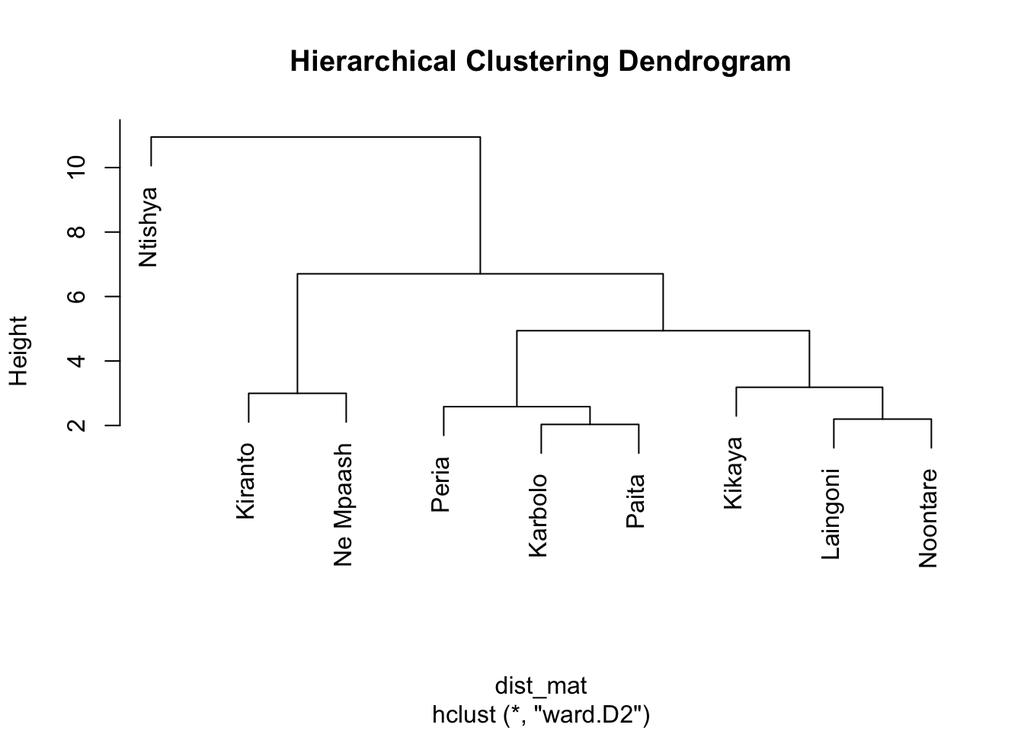

```r
# Compute distance matrix and apply clustering method
dist_mat <- dist(metrics.mat)
hc <- hclust(dist_mat, method = "ward.D2")
# ward.D2 creates compact, spherical clusters (often fits behavioral mode clustering).
# Visualization
plot(hc, main = "Hierarchical Clustering Dendrogram")
```

K-means clustering, which aims to partition the points into k groups such that the sum of squares from points to the assigned cluster centres is minimized.

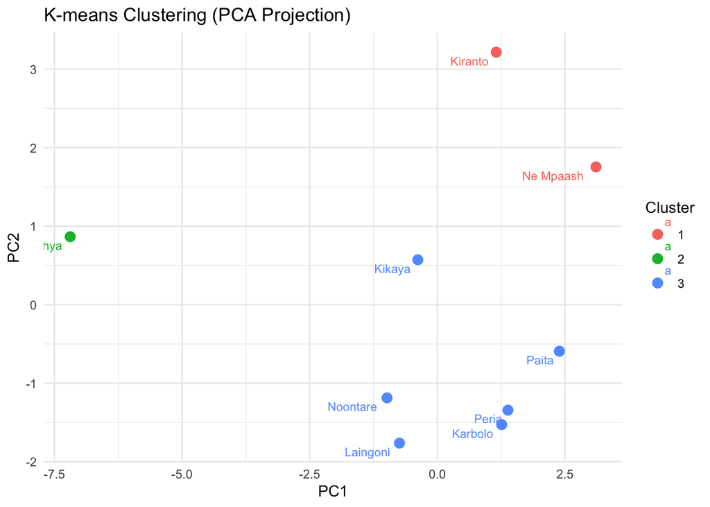

```r
set.seed(123)# reproducibility
kmeans_result <- kmeans(metrics.mat, centers = 3, nstart = 25) # when centers is a number (the number of clusters), a random set of (distinct) rows in x is chosen as the initial centres. nstart defines this initial set of rows.
metrics.df$cluster <- as.factor(kmeans_result$cluster) # turn cluster ID into factor

# Visualize using PCA projection onto first two principal components
pca <- prcomp(metrics.mat)
pca_df <- data.frame(pca$x[,1:2], id = rownames(metrics.mat), cluster = metrics.df$cluster)

ggplot(pca_df, aes(PC1, PC2, color = cluster, label = id)) +
  geom_point(size = 3) +
  geom_text(vjust = 1.5, hjust = 1.2, size = 3) +
  theme_minimal() +
  labs(title = "K-means Clustering (PCA Projection)", color = "Cluster")
```

**QUESTION:** From the track maps we created before, can you try to interpret the clustering results? Is 3 a seasonable number of clusters? Try different clustering numbers and see whether results are different.

Further readings:

- Abrahms, Briana, Dana P. Seidel, Eric Dougherty, Elliott L. Hazen, Steven J. Bograd, Alan M. Wilson, J. Weldon McNutt et al. “Suite of simple metrics reveals common movement syndromes across vertebrate taxa.” Movement ecology 5, no. 1 (2017): 12.

—————– (ﾉ◕ヮ◕)ﾉ*:･ﾟ✧ THE END :･ﾟ･ﾟ ——————